# warmup01-Uzziel-Valencia.Rmd

Uzziel Valencia

2/4/2019

## K-2S0

[figure not shown]

Snide Quote:

> “There were a lot of explosions for two people *blending in*.”

| Category | Specification |
| --- | --- |
| Manufacturer | Arakyd Industries |
| Model | KX- Series Security Droid |
| Applications | General Security |
| Squad | Rogue One |
| Status | **Deceased** |

Note: Source for this information can be found [here](https://starwars.fandom.com/wiki/K-2SO).

## Borne of the Earth

#### Mushroom + Farro Soup

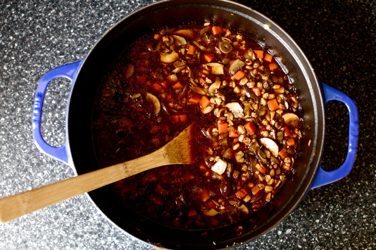

##### For this simple yet hardy soup, you can get as fancy or as simple as you want. It is sure to please everyone in your home with a nice warm meal that feels like a good hug.

### Ingredients

- 1/3 cup of dried mushroom (i.e. porcini)
- 2 tblspns cooking oil (vegetable, olive, etc.)
- 1 diced medium onion
- 1 diced medium carrot
- 2 cloves minced garlic
- 1 lb whole mushrooms (crimimi or brown)
- 1/2 cup of rinsed farro (or, barley, spelt, etc.)
- 6 cups of salt free broth (can be beef, vegetable, or chicken broth)
- 1/4 cup dry sherry
- 1 tblspn tomato paste
- 1 tblspn sherry vinegar
- Salt and Pepper to taste
- 1 Cup of water

### Equipment

- Measuring Cups
- Small/Medium bowl
- Deep Pot
- Strainer
- Cutting Board
- Cutting Knife

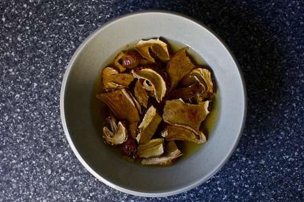

**Dried porcini Mushrooms**

### Preparation

1. Place dried mushrooms in small/ meduim bowl, cover with 1 cup of boiling water; let sit for 20 mins.
2. Chop fresh mushrooms to desired texture and size.
3. Heat oil in deep pot, saute oinions and carrots over medium heat until brown (10- 15 mins).
4. Add fresh mushrooms; cook until they release liquid (5- 10 mins).
5. Raise heat and add grain (farro, barley, etc.); saute for (5-10 mins).
6. Add broth, sherry, and tomato paste.
7. Remove soaking mushrooms from their liquid and finely chop them (keep the liquid).
8. Strain liquid and add to broth.
9. Add chopped mushrooms to the broth.
10. Season soup with salt + pepper, let simmer for 40 mins (until grains are tender).
11. Stir in sherry vinegar, adjust final seasoning; enjoy!

##### Notes:

- This recipe is great for Winter or early Fall
- The stock can be adjusted for diatery restrictions (i.e. veggie stock for vegans, or kosher/ halal stocks)
- Salt free stock should be used as mushrooms are naturally very salty
- Original recipe can be found [*here!*](https://smittenkitchen.com/2011/01/mushroom-and-farro-soup/)

## Euclidean Distance

### Definition

The **Euclidean distance** between points **p** and **q** is the length of the line segment connecting them $\overline{\textbf{(PQ)}}$.  
In Cartesian coordinates, if **p** $= (p_1, p_2,..., p_n)$ and **q** $= (q_1, q_2,..., q_n)$ are two points in Euclidean *n-space*, then the distance (d) from **p** to **q**, or from **q** to **p** is given by the Pythagorean formula:

$$d(\textbf{p,} \textbf{q}) = d(\textbf{q},\textbf{p}) = \sqrt{(q_1-p_1)^2 + (q_2 - p_2)^2 +...+ (q_n-p_n)^2}$$

$$=\sqrt{\sum_{i =1}^n (q_i-p_i)^2}.$$

The position of a point in a Euclidean *n-space* is a Euclidean vector. So, **p** and **q** may be represented as Euclidean vectors, starting from the origin of the space (initial point) with their tips (terminal points) ending at the two points. The **Euclidean norm**, or **Euclidean length**, or **magnitude** of a vector measures the length of the vector:

$$\left\|\textbf{p}\right\| = \sqrt{p_1^2 + p_2^2 +...+ p_n^2} = \sqrt{\textbf{p} \cdot \textbf{p}}$$

where the last expression involves the dot product.